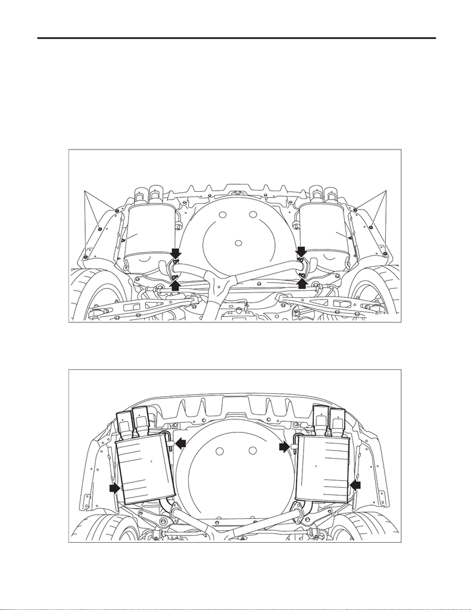

EX(w/o STI)-53

Muffler

EXHAUST

5. Muffler

A: REMOVAL

CAUTION:

Vehicle components are extremely hot after driving. Be wary of receiving burns from heated parts.

1) Lift up the vehicle.

2) Remove the clip (A) which holds the cover - rear bumper side to the vehicle and rear bumper.

NOTE:

This procedure is required to facilitate the removal/installation of the muffler.

3) Remove the bolts and self-locking nuts which secure the rear exhaust pipe to the muffler.

4) Apply a coat of spray type lubricant to the mating area of cushion rubber.

5) Remove the muffler from the cushion rubber.

CAUTION:

Be careful not to drop the muffler during removal.

EX-03129

(A)

(A)

(A)

(A)

EX-03130

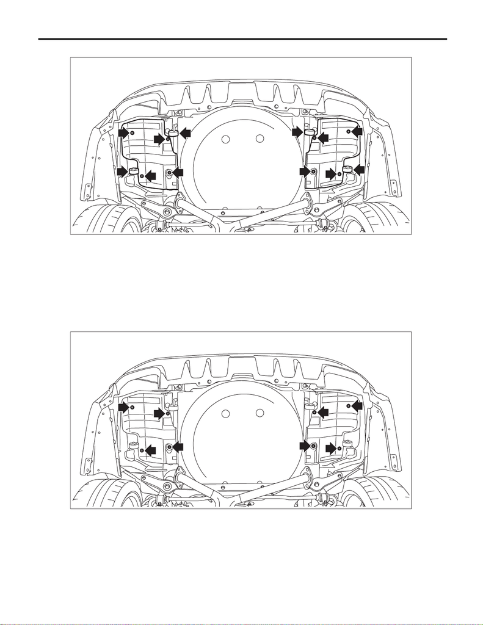

EX(w/o STI)-54

Muffler

EXHAUST

6) Remove the cushion rubber and rear exhaust cover from the vehicle.

B: INSTALLATION

Install in the reverse order of removal.

NOTE:

• Use a new gasket and self-locking nut.

ing.

Tightening torque:

10 N·m (1.0 kgf-m, 7.4 ft-lb)

EX-03131

EX-03132

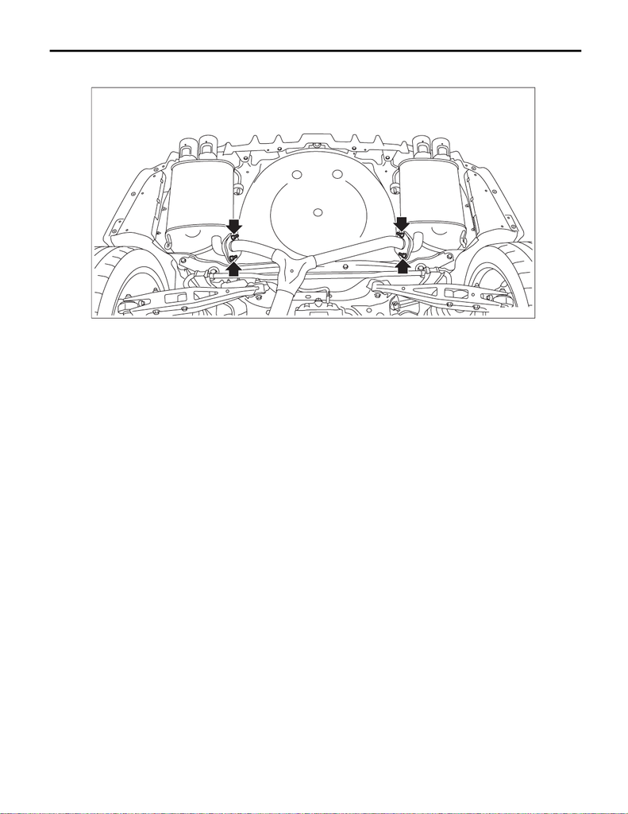

EX(w/o STI)-55

Muffler

EXHAUST

Tightening torque:

48 N·m (4.9 kgf-m, 35.4 ft-lb)

C: INSPECTION

1) Check the connections and welded parts for exhaust leaks.

2) Make sure there are no holes or rusting.

3) Check the cushion rubber for wear or crack.

EX-03128

[figure not shown]

EX(w/o STI)-56

Muffler

EXHAUST

[figure not shown]

COOLING

CO(w/o STI)

Page

1. General Description ...................................................................................2

2. Radiator Fan System .................................................................................7

3. Engine Coolant .........................................................................................13

4. Water Pump .............................................................................................16

5. Water Pipe Assembly ...............................................................................19

6. Thermostat ...............................................................................................33

7. Radiator ....................................................................................................37

8. Radiator Cap ............................................................................................45

9. Radiator Main Fan and Fan Motor ...........................................................46

10. Radiator Sub Fan and Fan Motor .............................................................49

11. Reservoir Tank .........................................................................................52

12. Engine Cooling System Trouble in General .............................................53